# Wine classification

Jayadeep

16 Nov 2017

# 1 Introduction

In this first study case, the wine data set, we have 13 chemical concentrations describing wine samples from three cultivars. (cultivars: A plant variety that has been produced in cultivation by selective breeding.)

```r
url <- 'https://archive.ics.uci.edu/ml/machine-learning-databases/wine/wine.data'
wine <- read.csv(url)
colnames(wine) <- c('Type','Alcohol', 'Malic', 'Ash', 'Alcalinity', 'Magnesium', 'Phenols', 'Flavanoids','Nonflavanoids', 'Proanthocyanins', 'Color', 'Hue', 'Dilution', 'Proline')
head(wine)
```

```
##   Type Alcohol Malic  Ash Alcalinity Magnesium Phenols Flavanoids
## 1    1   13.20  1.78 2.14       11.2       100    2.65       2.76
## 2    1   13.16  2.36 2.67       18.6       101    2.80       3.24
## 3    1   14.37  1.95 2.50       16.8       113    3.85       3.49
## 4    1   13.24  2.59 2.87       21.0       118    2.80       2.69
## 5    1   14.20  1.76 2.45       15.2       112    3.27       3.39
## 6    1   14.39  1.87 2.45       14.6        96    2.50       2.52
##   Nonflavanoids Proanthocyanins Color  Hue Dilution Proline
## 1          0.26            1.28  4.38 1.05     3.40    1050
## 2          0.30            2.81  5.68 1.03     3.17    1185
## 3          0.24            2.18  7.80 0.86     3.45    1480
## 4          0.39            1.82  4.32 1.04     2.93     735
## 5          0.34            1.97  6.75 1.05     2.85    1450
## 6          0.30            1.98  5.25 1.02     3.58    1290
```

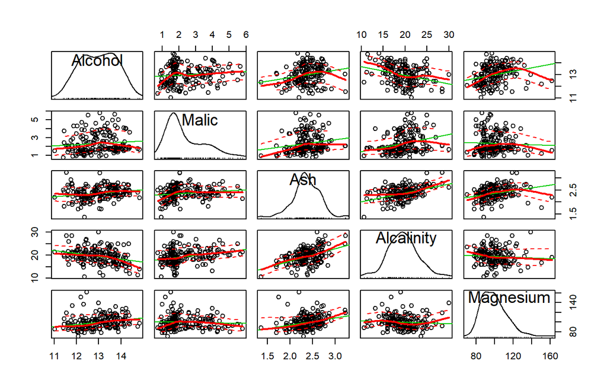

```r
library(car)
scatterplotMatrix(wine[2:6])
```

The purpose of linear discriminant analysis (LDA) in this example is to find the linear combinations of the original variables (the 13 chemical concentrations here) that gives the best possible separation between the groups (wine cultivars here) in our data set. Linear discriminant analysis is also known as “canonical discriminant analysis”, or simply “discriminant analysis”.

If we want to separate the wines by cultivar, the wines come from three different cultivars, so the number of groups G=3G=3, and the number of variables is 13 (13 chemicals’ concentrations; p=13p=13). The maximum number of useful discriminant functions that can separate the wines by cultivar is the minimum of G−1 and p, and so in this case it is the minimum of 2 and 13, which is 2. Thus, we can find at most 2 useful discriminant functions to separate the wines by cultivar, using the 13 chemical concentration variables.

You can carry out a linear discriminant analysis using the “lda()” function from the R MASS package. To use this function, we first need to install the MASS R package.

# 2 Model Fitting

```r
# install.packages('MASS')
library(MASS)
wine.lda <- lda(Type ~ ., data=wine)
```

To get the values of the loadings of the discriminant functions for the wine data, we can type:

```r
wine.lda
```

```
## Call:
## lda(Type ~ ., data = wine)
##
## Prior probabilities of groups:
##         1         2         3
## 0.3276836 0.4011299 0.2711864
##
## Group means:
##    Alcohol    Malic      Ash Alcalinity Magnesium  Phenols Flavanoids
## 1 13.73638 2.015862 2.456034   17.06207  105.9828 2.840862  2.9810345
## 2 12.27873 1.932676 2.244789   20.23803   94.5493 2.258873  2.0808451
## 3 13.15375 3.333750 2.437083   21.41667   99.3125 1.678750  0.7814583
##   Nonflavanoids Proanthocyanins    Color       Hue Dilution   Proline
## 1     0.2901724        1.892586 5.526379 1.0624138 3.144655 1116.5862
## 2     0.3636620        1.630282 3.086620 1.0562817 2.785352  519.5070
## 3     0.4475000        1.153542 7.396250 0.6827083 1.683542  629.8958
##
## Coefficients of linear discriminants:
##                          LD1           LD2
## Alcohol         -0.407338108  0.8718851641
## Malic            0.171369005  0.3036138673
## Ash             -0.350833426  2.3433262926
## Alcalinity       0.155392632 -0.1471841565
## Magnesium       -0.003023265 -0.0005503898
## Phenols          0.633363249 -0.0357006981
## Flavanoids      -1.658806773 -0.4751178427
## Nonflavanoids   -1.560673918 -1.6200997722
## Proanthocyanins  0.124497887 -0.3084356285
## Color            0.355593960  0.2492418348
## Hue             -0.812672717 -1.5023785169
## Dilution        -1.191107695  0.0571327716
## Proline         -0.002639133  0.0028737679
##
## Proportion of trace:
##    LD1    LD2
## 0.6879 0.3121
```

The “proportion of trace” is the percentage separation achieved by each discriminant function.

## 2.1 A Stacked Histogram of the LDA Values

A nice way of displaying the results of a linear discriminant analysis (LDA) is to make a stacked histogram of the values of the discriminant function for the samples from different groups (different wine cultivars in our example).

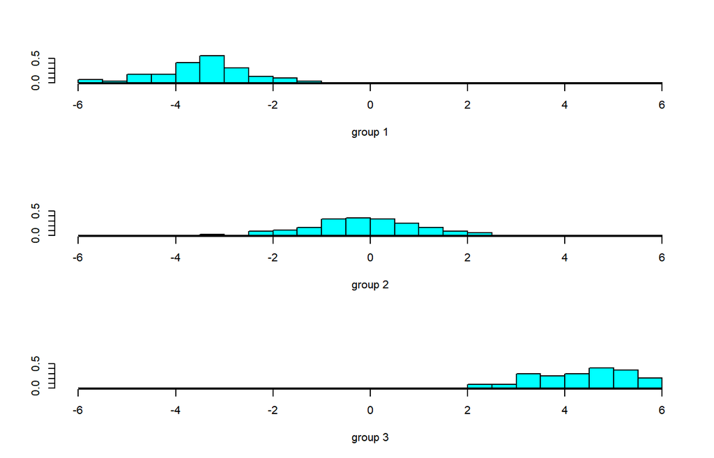

```r
wine.lda.values <- predict(wine.lda)
ldahist(data = wine.lda.values$x[,1], g=wine.lda.values$class)
```

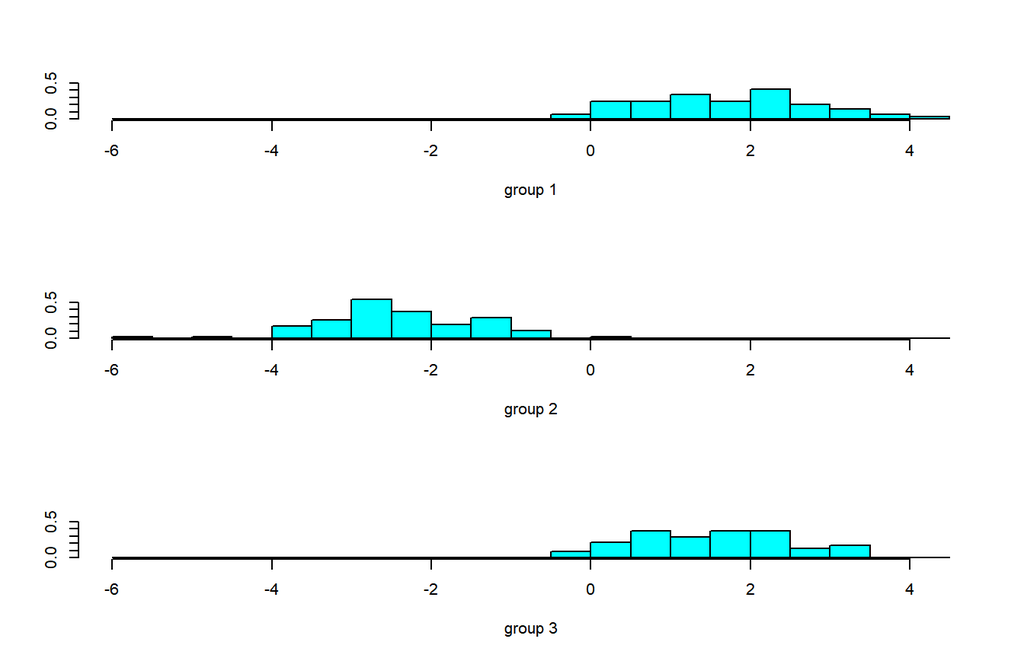

```r
ldahist(data = wine.lda.values$x[,2], g=wine.lda.values$class)
```

## 2.2 Scatterplots of the Discriminant Functions

We can obtain a scatterplot of the best two discriminant functions, with the data points labelled by cultivar, by typing:

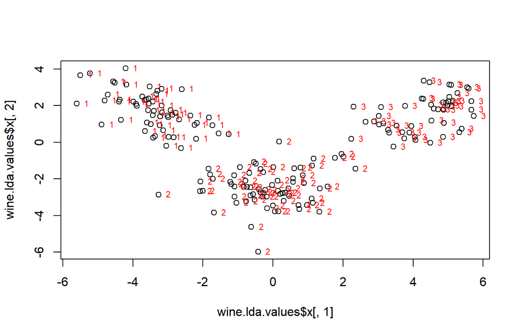

```r
plot(wine.lda.values$x[,1],wine.lda.values$x[,2]) # make a scatterplot
text(wine.lda.values$x[,1],wine.lda.values$x[,2],wine.lda.values$class,cex=0.7,pos=4,col="red") # add labels
```